# 1.1.6 Load spatial reference layers

This notebook loads and stages reusable NYC spatial reference layers for downstream geospatial analysis and multimodal mobility integration.

The workflow: 1. Load and inspect the NYC Taxi Zone spatial reference layer. 2. Perform lightweight QA checks on schema integrity, polygon geometry validity, coordinate systems, and geographic coverage. 3. Investigate repeated taxi zone identifiers and confirm whether they represent duplicate records or legitimate multi-part geographic regions. 4. Validate the spatial extent of the loaded geometries and visually render the polygon layer. 5. Save the staged spatial reference dataset as a parquet file for downstream spatial joins and aggregation workflows.

## 1.1.6.1 Load spatial data and light QA

This section loads the NYC Taxi Zone polygon layer and performs an initial inspection of schema structure, missingness, duplicate records, borough coverage, and basic geographic metadata before deeper geospatial QA.

```python
from pathlib import Path

import pandas as pd

import geopandas as gpd
from shapely import wkt
import matplotlib.pyplot as plt

from project_branding import BRAND_COLORS

pd.set_option("display.max_colwidth", None)
```

```python
# ---------------------------------------------------------------------
# Load NYC Taxi Zone spatial reference data
# ---------------------------------------------------------------------

SOURCE_DATA_DIR = Path("source_data")
TAXI_ZONES_PATH = SOURCE_DATA_DIR / "NYC_Taxi_Zones_20260526.csv"

taxi_zones_raw = pd.read_csv(
    TAXI_ZONES_PATH,
    low_memory=False
)

print("Taxi zones raw shape:", taxi_zones_raw.shape)
taxi_zones_raw.info()

taxi_zones_raw.head()
```

```
Taxi zones raw shape: (263, 6)
<class 'pandas.core.frame.DataFrame'>
RangeIndex: 263 entries, 0 to 262
Data columns (total 6 columns):
 #   Column          Non-Null Count  Dtype
---  ------          --------------  -----
 0   Shape Geometry  263 non-null    object
 1   Shape Length    263 non-null    float64
 2   Shape Area      263 non-null    float64
 3   Zone            263 non-null    object
 4   Location ID     263 non-null    int64
 5   Borough         263 non-null    object
dtypes: float64(2), int64(1), object(3)
memory usage: 12.5+ KB
```

|  | Shape Geometry | Shape Length | Shape Area | Zone | Location ID | Borough |
| --- | --- | --- | --- | --- | --- | --- |
| 0 | MULTIPOLYGON (((-74.18445299999996 40.69499599999993, -74.18448899999999 40.69509499999991, -74.18449799999996 40.69518499999991, -74.18438099999997 40.69587799999992, -74.18428199999994 40.6962109999… | 0.116357 | 0.000782 | Newark Airport | 1 | EWR |
| 1 | MULTIPOLYGON (((-73.82337597260663 40.63898704717677, -73.82277105438692 40.63557691408516, -73.82265046764824 40.63536884414312, -73.82253791037438 40.63515817971123, -73.82243347854202 40.6349451005… | 0.433470 | 0.004866 | Jamaica Bay | 2 | Queens |
| 2 | MULTIPOLYGON (((-73.84792614099985 40.871342233999954, -73.84725144800001 40.87098705199996, -73.84699273699992 40.870852887999895, -73.84640766399981 40.870554300999935, -73.84608957099984 40.8703897… | 0.084341 | 0.000314 | Allerton/Pelham Gardens | 3 | Bronx |
| 3 | MULTIPOLYGON (((-73.97177410965318 40.72582128133709, -73.97179142961485 40.72581422114913, -73.97181650587731 40.7258149667526, -73.97185935830923 40.725582969030356, -73.97187437695213 40.7255031160… | 0.043567 | 0.000112 | Alphabet City | 4 | Manhattan |
| 4 | MULTIPOLYGON (((-74.17421738099989 40.56256808599992, -74.17348507999998 40.56226748999998, -74.17225507699992 40.561704836999944, -74.17191921399996 40.561551718999986, -74.17185166499996 40.56152092… | 0.092146 | 0.000498 | Arden Heights | 5 | Staten Island |

```python
print("NA count:", taxi_zones_raw.isna().sum())
print("Describe:", taxi_zones_raw.describe())
print("Duplicates:", taxi_zones_raw.duplicated().sum())
```

```
NA count: Shape Geometry    0
Shape Length      0
Shape Area        0
Zone              0
Location ID       0
Borough           0
dtype: int64
Describe:        Shape Length  Shape Area  Location ID
count    263.000000  263.000000   263.000000
mean       0.094269    0.000402   131.984791
std        0.054594    0.000482    76.073787
min        0.014306    0.000006     1.000000
25%        0.054722    0.000133    66.500000
50%        0.084341    0.000268   132.000000
75%        0.119488    0.000480   197.500000
max        0.433470    0.004866   263.000000
Duplicates: 0
```

```python
print(taxi_zones_raw['Borough'].value_counts())
```

```
Borough
Queens           69
Manhattan        69
Brooklyn         61
Bronx            43
Staten Island    20
EWR               1
Name: count, dtype: int64
```

## 1.1.6.2 QA geospatial data

Let's load the NYC Taxi Zone spatial reference layer and performs a lightweight QA pass to validate schema integrity, polygon availability, coordinate system consistency, and basic geographic coverage before staging the dataset for downstream spatial joins and multimodal mobility analysis.

```python
# ---------------------------------------------------------------------
# Stage taxi zone polygons
# ---------------------------------------------------------------------

# Create working copy
taxi_zones = taxi_zones_raw.copy()

# Convert WKT multipolygon text into shapely geometry objects
taxi_zones["geometry"] = taxi_zones["Shape Geometry"].apply(wkt.loads)

# Convert dataframe into GeoDataFrame with WGS84 coordinates
# EPSG:4326 = standard latitude / longitude coordinate system
taxi_zones = gpd.GeoDataFrame(
    taxi_zones,
    geometry="geometry",
    crs="EPSG:4326"
)

# Keep only relevant fields and standardize column names
taxi_zones = taxi_zones[
    [
        "Location ID",
        "Zone",
        "Borough",
        "Shape Length",
        "Shape Area",
        "geometry",
    ]
].rename(
    columns={
        "Location ID": "location_id",
        "Zone": "zone",
        "Borough": "borough",
        "Shape Length": "shape_length",
        "Shape Area": "shape_area",
    }
)

taxi_zones.head()
```

|  | location_id | zone | borough | shape_length | shape_area | geometry |
| --- | --- | --- | --- | --- | --- | --- |
| 0 | 1 | Newark Airport | EWR | 0.116357 | 0.000782 | MULTIPOLYGON (((-74.18445 40.695, -74.18449 40.69509, -74.1845 40.69518, -74.18438 40.69588, -74.18428 40.69621, -74.18402 40.69707, -74.18391 40.69751, -74.18375 40.69779, -74.18363 40.69833, -74.183… |
| 1 | 2 | Jamaica Bay | Queens | 0.433470 | 0.004866 | MULTIPOLYGON (((-73.82338 40.63899, -73.82277 40.63558, -73.82265 40.63537, -73.82254 40.63516, -73.82243 40.63495, -73.82234 40.63473, -73.82225 40.63451, -73.82217 40.63429, -73.8221 40.63407, -73.8… |
| 2 | 3 | Allerton/Pelham Gardens | Bronx | 0.084341 | 0.000314 | MULTIPOLYGON (((-73.84793 40.87134, -73.84725 40.87099, -73.84699 40.87085, -73.84641 40.87055, -73.84609 40.87039, -73.84578 40.87023, -73.84517 40.86991, -73.84488 40.86976, -73.84442 40.86952, -73.… |
| 3 | 4 | Alphabet City | Manhattan | 0.043567 | 0.000112 | MULTIPOLYGON (((-73.97177 40.72582, -73.97179 40.72581, -73.97182 40.72581, -73.97186 40.72558, -73.97187 40.7255, -73.97188 40.72542, -73.97191 40.72529, -73.97193 40.72518, -73.97194 40.72516, -73.9… |
| 4 | 5 | Arden Heights | Staten Island | 0.092146 | 0.000498 | MULTIPOLYGON (((-74.17422 40.56257, -74.17349 40.56227, -74.17226 40.5617, -74.17192 40.56155, -74.17185 40.56152, -74.17223 40.56114, -74.17245 40.56089, -74.17322 40.56008, -74.17359 40.5597, -74.17… |

```python
# ---------------------------------------------------------------------
# Light spatial QA checks
# ---------------------------------------------------------------------

print("Shape:", taxi_zones.shape)

# Confirm coordinate reference system
print("CRS:", taxi_zones.crs)

# Check for invalid polygon geometries
print(
    "Invalid geometries:",
    (~taxi_zones.geometry.is_valid).sum()
)

# Check for empty polygon records
print(
    "Empty geometries:",
    taxi_zones.geometry.is_empty.sum()
)

# Check for missing geometry values
print(
    "Missing geometries:",
    taxi_zones.geometry.isna().sum()
)

# Validate taxi zone identifier uniqueness
print(
    "Unique location IDs:",
    taxi_zones["location_id"].nunique()
)

print(
    "Duplicate location IDs:",
    taxi_zones["location_id"].duplicated().sum()
)
```

```
Shape: (263, 6)
CRS: EPSG:4326
Invalid geometries: 0
Empty geometries: 0
Missing geometries: 0
Unique location IDs: 260
Duplicate location IDs: 3
```

```python
dupes = taxi_zones[taxi_zones["location_id"].duplicated(keep = False)]
display(dupes)
```

|  | location_id | zone | borough | shape_length | shape_area | geometry |
| --- | --- | --- | --- | --- | --- | --- |
| 55 | 56 | Corona | Queens | 0.056848 | 0.000181 | MULTIPOLYGON (((-73.85361 40.7475, -73.85325 40.74682, -73.85292 40.74618, -73.85258 40.74551, -73.85224 40.74484, -73.8519 40.74418, -73.85155 40.74351, -73.85135 40.74312, -73.85121 40.74284, -73.85… |
| 56 | 56 | Corona | Queens | 0.019271 | 0.000018 | MULTIPOLYGON (((-73.85131 40.74984, -73.85443 40.74885, -73.85447 40.74894, -73.85479 40.74956, -73.85514 40.75023, -73.85548 40.75089, -73.85583 40.75158, -73.85456 40.75196, -73.85498 40.75278, -73.… |
| 102 | 103 | Governor's Island/Ellis Island/Liberty Island | Manhattan | 0.014306 | 0.000006 | MULTIPOLYGON (((-74.04389 40.69018, -74.04351 40.68969, -74.04274 40.69005, -74.04278 40.69012, -74.0427 40.69016, -74.04255 40.68996, -74.04264 40.68993, -74.04269 40.69, -74.04347 40.68964, -74.0435… |
| 103 | 103 | Governor's Island/Ellis Island/Liberty Island | Manhattan | 0.021221 | 0.000012 | MULTIPOLYGON (((-74.03995 40.70089, -74.03945 40.70053, -74.03938 40.70058, -74.03771 40.69934, -74.0381 40.69904, -74.03823 40.69837, -74.039 40.69837, -74.03934 40.69812, -74.03993 40.69854, -74.040… |
| 104 | 103 | Governor's Island/Ellis Island/Liberty Island | Manhattan | 0.077425 | 0.000369 | MULTIPOLYGON (((-74.01675 40.69334, -74.0154 40.69307, -74.01535 40.69322, -74.01541 40.69324, -74.01539 40.6933, -74.01517 40.69326, -74.01519 40.6932, -74.01525 40.69321, -74.01531 40.69305, -74.015… |

Findings: The taxi zone layer looked clean overall, with valid polygon geometries, no missing spatial records, and full NYC borough coverage. A few taxi zone IDs appeared more than once, but inspection showed that these were legitimate split geographic regions — classic NYC stuff like islands and disconnected neighborhood fragments rather than bad spatial data.

```python
# Confirm polygon coordinate bounds roughly align with the NYC region
# total_bounds returns: [min_longitude, min_latitude, max_longitude, max_latitude]
taxi_zones.total_bounds
```

```
array([-74.25559136,  40.4961154 , -73.70000906,  40.91553278])
```

Findings: The polygon coordinate bounds aligned with the expected NYC geographic region, with longitude and latitude ranges consistent with publicly reported NYC coordinate ranges centered around approximately 40.73, -73.94.: [https://www\.latlong\.net/place/new\-york\-city\-ny\-usa\-1848\.html](https://www%5C.latlong%5C.net/place/new%5C-york%5C-city%5C-ny%5C-usa%5C-1848%5C.html)

## 1.1.6.3 Visualize polygons on map

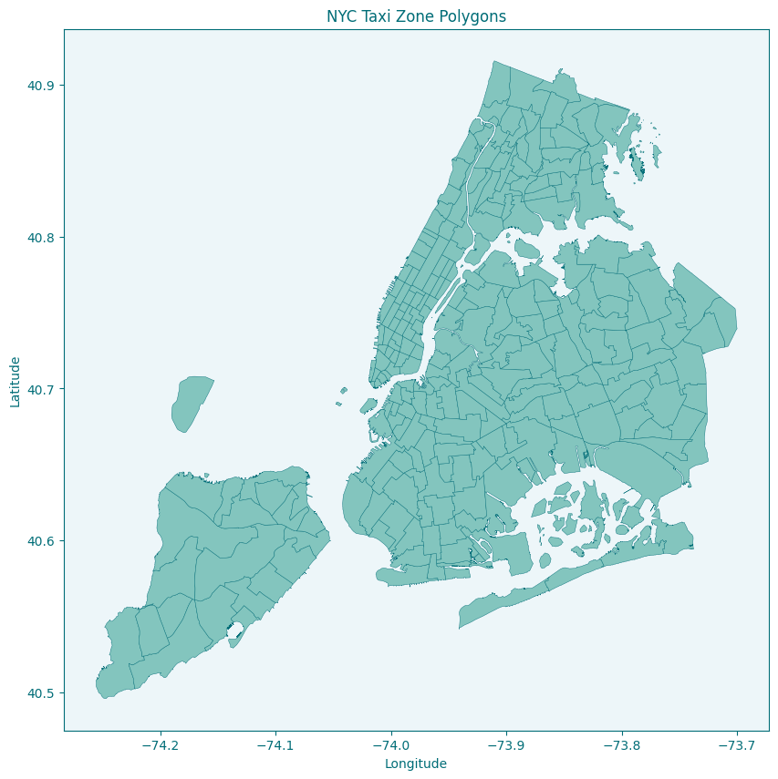

```python
# Visual sanity check: render taxi zone polygons before staging
fig, ax = plt.subplots(figsize=(10, 10))
fig.patch.set_facecolor("white")
ax.set_facecolor(BRAND_COLORS["ice"])

taxi_zones.plot(
    ax=ax,
    facecolor=BRAND_COLORS["seafoam"],
    edgecolor=BRAND_COLORS["dark_teal"],
    linewidth=0.3,
)

ax.set_title("NYC Taxi Zone Polygons", color=BRAND_COLORS["dark_teal"])
ax.set_xlabel("Longitude", color=BRAND_COLORS["dark_teal"])
ax.set_ylabel("Latitude", color=BRAND_COLORS["dark_teal"])
ax.tick_params(colors=BRAND_COLORS["dark_teal"])

for spine in ax.spines.values():
    spine.set_color(BRAND_COLORS["dark_teal"])

plt.show()
```

```python
# Let's create an interactive map that lets us hover over zones and inspect zone metadata.

taxi_zones_interactive = taxi_zones.copy()

# Create centroid coordinates for hover tooltip
taxi_zones_interactive["centroid_lon"] = taxi_zones_interactive.geometry.centroid.x
taxi_zones_interactive["centroid_lat"] = taxi_zones_interactive.geometry.centroid.y

taxi_zones_interactive.explore(
    tooltip=[
        "zone",
        "borough",
        "location_id",
        "centroid_lat",
        "centroid_lon",
    ],
    popup=[
        "zone",
        "borough",
        "location_id",
        "centroid_lat",
        "centroid_lon",
    ],
    tiles="CartoDB positron",
    style_kwds={
        "fillColor": BRAND_COLORS["seafoam"],
        "fillOpacity": 0.35,
        "color": BRAND_COLORS["dark_teal"],
        "weight": 0.5,
    },
)
```

[interactive chart not shown]

## 1.1.6.4 Stage the spatial layer

```python
# ---------------------------------------------------------------------
# Save spatial data into Parquet
# ---------------------------------------------------------------------

PIPELINE_DATA_DIR = Path("pipeline_data")
PIPELINE_DATA_DIR.mkdir(exist_ok=True)

TAXI_ZONES_PARQUET_PATH = (
    PIPELINE_DATA_DIR / "1.1.6.nyc_taxi_zones.parquet"
)

taxi_zones.to_parquet(
    TAXI_ZONES_PARQUET_PATH,
    index=False
)

print(f"Saved staged taxi zone spatial data to: {TAXI_ZONES_PARQUET_PATH}")
```

```
Saved staged taxi zone spatial data to: pipeline_data/1.1.6.nyc_taxi_zones.parquet
```

The NYC Taxi Zone spatial reference layer was successfully loaded, validated, and staged for downstream geospatial analysis. QA checks confirmed valid polygon geometries, complete spatial coverage, and consistent coordinate system metadata, while investigation of repeated taxi zone identifiers showed that they reflected legitimate multi-part geographic regions rather than duplicate spatial records.

The staged taxi zone parquet dataset is now ready for downstream spatial joins, roadway enrichment, multimodal aggregation, and geospatial visualization workflows.

```python
display(taxi_zones[['location_id','zone','borough']])
```

|  | location_id | zone | borough |
| --- | --- | --- | --- |
| 0 | 1 | Newark Airport | EWR |
| 1 | 2 | Jamaica Bay | Queens |
| 2 | 3 | Allerton/Pelham Gardens | Bronx |
| 3 | 4 | Alphabet City | Manhattan |
| 4 | 5 | Arden Heights | Staten Island |
| ... | ... | ... | ... |
| 258 | 259 | Woodlawn/Wakefield | Bronx |
| 259 | 260 | Woodside | Queens |
| 260 | 261 | World Trade Center | Manhattan |
| 261 | 262 | Yorkville East | Manhattan |
| 262 | 263 | Yorkville West | Manhattan |

263 rows × 3 columns

[figure not shown]